# gusto_stai_scoring

Fran Querdasi

1/4/2021

Note: this script uses scores already calculated by the GUSTO team (rather than calculating scores)

# Setup

## Load libraries

```r
suppressPackageStartupMessages({
    library(tidyverse)
    library(knitr)
    library(readr)
    library(psych)
    library(lubridate)
    library(readxl)
    library(stringr)
})
```

## Import data

**Note:** Filepaths (code for this chunk) are not shown

# STAI

## STAI Scores

### Select STAI Scores

**Notes on GUSTO STAI Scoring**

- _total = raw score
- _prorated = For respondents who omit one or two items on either scale, the prorated full-scale score was obtained by: determine the mean weighted score for the scale items to which the individual responded; multiply this value by 20; round the result to the next higher whole number. However if three or more items are omitted, a score was not calculated
- _imputed = hot deck imputation

```r
# get variables that determine how many questions were
# answered (out of 21)
stai_complete_vars <- mh_data %>%
    dplyr::select(matches("(STAI)(.*)(qns)")) %>%
    names()

# get score variables
stai_score_vars <- mh_data %>%
    dplyr::select(matches("(STAI)(.*)(raw|prorated|imputed)")) %>%
    names()

stai_vars = append(stai_complete_vars, stai_score_vars)

# select scores
stai_data <- mh_data %>%
    dplyr::select(subjid = SubjectID, all_of(stai_vars))
```

### Filter scores if less than 90% of questions answered (less than 18 out of 20 for state or trait)

*Important note:* the STAI data after filtering includes anyone who has either state or trait data, or both - analyses will filter for STAI version of interest being complete enough

```r
# reported at pregnancy week 26
pw26_stai_data <- stai_data %>%
    dplyr::select(subjid, contains("pw26"))

pw26_stai_data <- pw26_stai_data %>%
    filter(STAI_qns_answered_state_pw26 > 17 | STAI_qns_answered_trait_pw26 >
        17)

# reported at child age 3 months
m3_stai_data <- stai_data %>%
    dplyr::select(subjid, matches("(m3)$"))

m3_stai_data <- m3_stai_data %>%
    filter(STAI_qns_answered_state_m3 > 17 | STAI_qns_answered_trait_m3 >
        17)

# reported at child age 12 months
m12_stai_data <- stai_data %>%
    dplyr::select(subjid, contains("m12"))

m12_stai_data <- m12_stai_data %>%
    filter(STAI_qns_answered_state_m12 > 17 | STAI_qns_answered_trait_m12 >
        17)

# reported at child age 24 months
m24_stai_data <- stai_data %>%
    dplyr::select(subjid, contains("m24"))

m24_stai_data <- m24_stai_data %>%
    filter(STAI_qns_answered_state_m24 > 17 | STAI_qns_answered_trait_m24 >
        17)

# reported at child age 36 months
m36_stai_data <- stai_data %>%
    dplyr::select(subjid, contains("m36"))

m36_stai_data <- m36_stai_data %>%
    filter(STAI_qns_answered_state_m36 > 17 | STAI_qns_answered_trait_m36 >
        17)

# reported at child age 4.5 years
yr4.5_stai_data <- stai_data %>%
    dplyr::select(subjid, contains("yr4.5"))

yr4.5_stai_data <- yr4.5_stai_data %>%
    filter(STAI_qns_answered_state_yr4.5 > 17 | STAI_qns_answered_trait_yr4.5 >
        17)

# reported at child age 6 years
yr6_stai_data <- stai_data %>%
    dplyr::select(subjid, contains("yr6"))

yr6_stai_data <- yr6_stai_data %>%
    filter(STAI_qns_answered_state_yr6 > 17)  #year 6 STAI data from gusto is missing trait scores


# merge timepoints
stai_complete_data <- pw26_stai_data %>%
    left_join(m3_stai_data, by = "subjid") %>%
    left_join(m12_stai_data, by = "subjid") %>%
    left_join(m24_stai_data, by = "subjid") %>%
    left_join(m36_stai_data, by = "subjid") %>%
    left_join(yr4.5_stai_data, by = "subjid") %>%
    left_join(yr6_stai_data, by = "subjid")
```

### STAI “clinical cutoff” grouping variable for STAI-S at pw26 (pregnancy week 26)

40 = cutoff for clinical levels of anxiety

```r
stai_complete_data <- stai_complete_data %>%
    mutate(stai_state_above_clin_cutoff_pw26 = ifelse(STAI_prorated_state_pw26 >
        40, 1, 0))
```

### STAI descriptive statistics

```r
# check that the score ranges make sense (range maximum
# allowed for state or trait is 20-80, total is 40-160)
stai_complete_data %>%
    summarise_all(list(min, max), na.rm = TRUE)  #yes, mins and maxes make sense
```

```
## # A tibble: 1 × 156
##   subjid_fn1 STAI_qns_…¹ STAI_…² STAI_…³ STAI_…⁴ STAI_…⁵ STAI_…⁶ STAI_…⁷ STAI_…⁸
##   <chr>            <dbl>   <dbl>   <dbl>   <dbl>   <dbl>   <dbl>   <dbl>   <dbl>
## 1 010-04002            0       0      18      19      20      20      12      20
## # … with 147 more variables: STAI_prorated_trait_pw26_fn1 <dbl>,
## #   STAI_raw_total_pw26_fn1 <dbl>, STAI_imputed_total_pw26_fn1 <dbl>,
## #   STAI_prorated_total_pw26_fn1 <dbl>, STAI_qns_answered_state_m3_fn1 <dbl>,
## #   STAI_qns_answered_trait_m3_fn1 <dbl>, STAI_qns_answered_total_m3_fn1 <dbl>,
## #   STAI_raw_state_m3_fn1 <dbl>, STAI_imputed_state_m3_fn1 <dbl>,
## #   STAI_prorated_state_m3_fn1 <dbl>, STAI_raw_trait_m3_fn1 <dbl>,
## #   STAI_imputed_trait_m3_fn1 <dbl>, STAI_prorated_trait_m3_fn1 <dbl>, …
## # ℹ Use `colnames()` to see all variable names
```

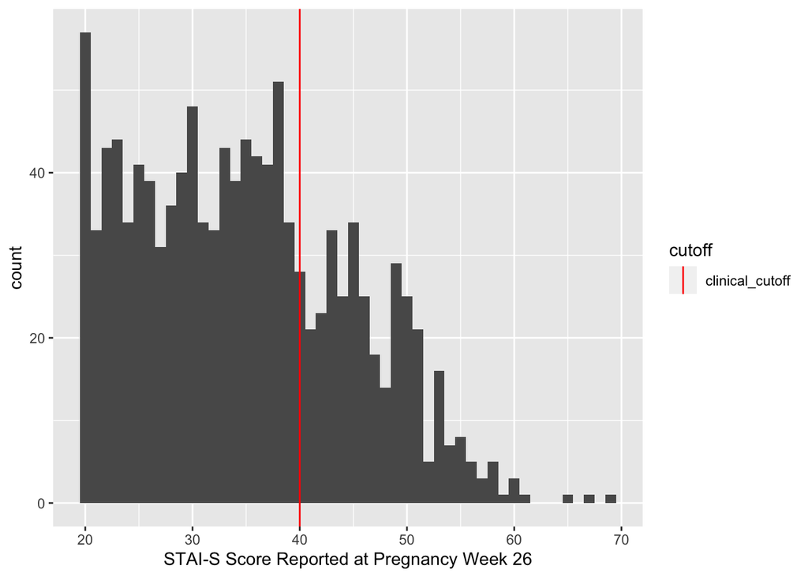

```r
# histograms of state and trait STAI scores reported at
# pregnancy week 26

# STAI state scores
stai_complete_data %>%
    ggplot(aes(STAI_prorated_state_pw26)) + geom_histogram(binwidth = 1) +
    geom_vline(aes(xintercept = 40, colour = "clinical_cutoff")) +
    scale_color_manual(name = "cutoff", values = c(clinical_cutoff = "red")) +
    xlab("STAI-S Score Reported at Pregnancy Week 26")
```

```r
# determine percentage of prorated state scores above
# clinical cutoff
stai_complete_data %>%
    filter(!is.na(STAI_prorated_state_pw26)) %>%
    group_by(STAI_prorated_state_pw26 > 40) %>%
    summarise(cnt = n()) %>%
    mutate(freq = round(cnt/sum(cnt), 3)) %>%
    arrange(desc(freq))
```

```
## # A tibble: 2 × 3
##   `STAI_prorated_state_pw26 > 40`   cnt  freq
##   <lgl>                           <int> <dbl>
## 1 FALSE                             835  0.72
## 2 TRUE                              325  0.28
```

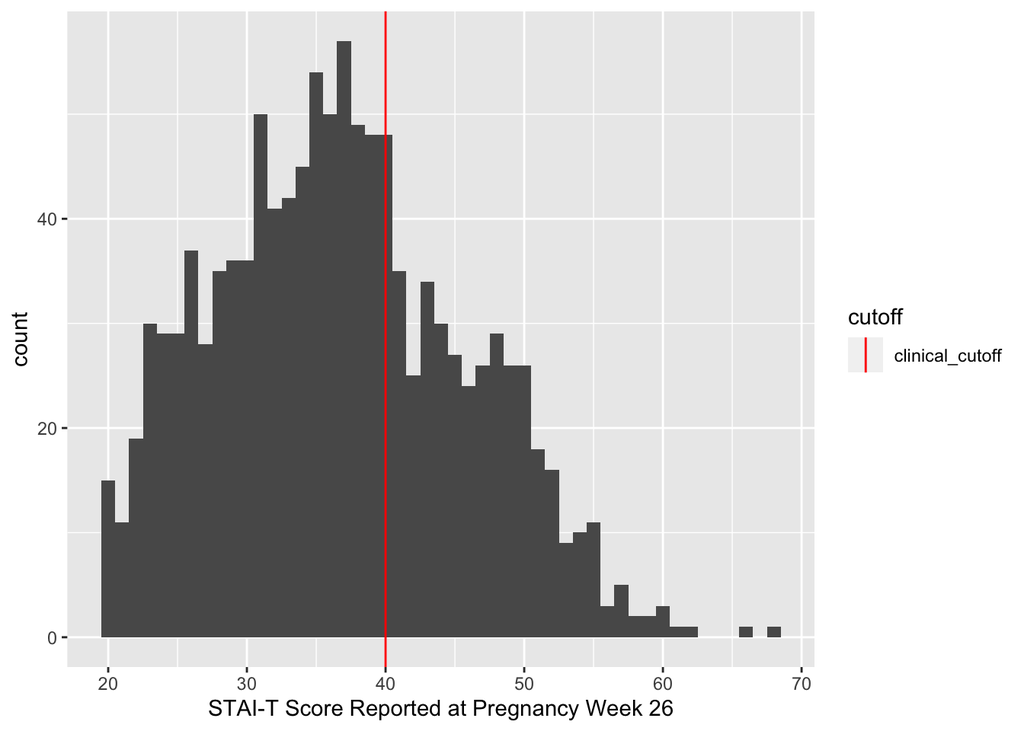

```r
ggsave("../../figures/descriptives/GUSTO_pw26_stai-state_hist.png",
    width = 10, height = 10)
# STAI trait scores
stai_complete_data %>%
    ggplot(aes(STAI_prorated_trait_pw26)) + geom_histogram(binwidth = 1) +
    geom_vline(aes(xintercept = 40, colour = "clinical_cutoff")) +
    scale_color_manual(name = "cutoff", values = c(clinical_cutoff = "red")) +
    xlab("STAI-T Score Reported at Pregnancy Week 26")
```

```r
# determine percentage of prorated trait scores above
# clinical cutoff
stai_complete_data %>%
    filter(!is.na(STAI_prorated_trait_pw26)) %>%
    group_by(STAI_prorated_trait_pw26 > 40) %>%
    summarise(cnt = n()) %>%
    mutate(freq = round(cnt/sum(cnt), 3)) %>%
    arrange(desc(freq))
```

```
## # A tibble: 2 × 3
##   `STAI_prorated_trait_pw26 > 40`   cnt  freq
##   <lgl>                           <int> <dbl>
## 1 FALSE                             789 0.684
## 2 TRUE                              365 0.316
```

```r
ggsave("../../figures/descriptives/GUSTO_pw26_stai-trait_hist.png",
    width = 10, height = 10)
```

## STAI prenatal items

Save prenatal items in a separate dataset for exploratory factor analysis with prenatal STAI and maternal CTQ scores.

```r
# get prenatal item vars
stai_prenatal_items <- mh_data %>%
    dplyr::select(matches("(STAI_qn[1-9][0-9]?_pw26)")) %>%
    names()

# select stai items
stai_prenatal_data <- mh_data %>%
    dplyr::select(subjid = SubjectID, all_of(stai_prenatal_items))

# make response values numeric
stai_prenatal_data <- stai_prenatal_data %>%
    mutate(across(contains("STAI"), ~str_sub(., 1, 1)))  #get just number parts of response

stai_prenatal_data <- stai_prenatal_data %>%
    mutate(across(contains("STAI"), ~as.numeric(.)))  #convert those number strings into numeric type
```

# Consolidate data

```r
mh_complete_data <- stai_complete_data

mh_reduced_data <-
  stai_complete_data %>%
  dplyr::select(
    subjid,
    contains("prorated"), #only include score type we decided to use
    stai_state_above_clin_cutoff_pw26
  )

#prenatal item data
mh_item_data <-
  stai_prenatal_data
```

# Save output files

```r
# complete scores
out_file_name_cscores <- str_c("../../data/mh_trajectories/GUSTO_STAI_complete_scores_",
    str_replace_all(Sys.Date(), "-", ""), ".csv")

write_csv(mh_complete_data, out_file_name_cscores)

# imputed scores
out_file_name_iscores <- str_c("../../data/mh_trajectories/GUSTO_STAI_imputed_scores_",
    str_replace_all(Sys.Date(), "-", ""), ".csv")

write_csv(mh_reduced_data, out_file_name_iscores)

# prenatal item level data
out_file_name_items <- str_c("../../data/pregnancy_mh/GUSTO_STAI_prenatal_items_",
    str_replace_all(Sys.Date(), "-", ""), ".csv")

write_csv(mh_item_data, out_file_name_items)
```